# Lab Assignment One: Exploring Table Data

Created by the **Dream Team:** Daniel Ryan, Josh Hascall, and Zach Suzuki

## Business Understanding

### Dataset overview

- This dataset is a large-scale survey of the satisfaction of customers of an airline.
  - This dataset provides demographic information for survey respondants and information on the flight they went on.
    - Age and gender of the respondents
    - What class the respondents travelled in
    - How far they travelled
    - Whether the travel was for personal or business reasons and if the passenger is a "loyal" customer
    - How much the flight was delayed on arrival or departure
  - Additionally, the dataset includes the responses to a large survey containing multiple fields. The responses are ranked from 0-5 (unhappy or NA - Extremely Satisfied)
    - Wi-Fi service
    - Departure/arrival time
    - Ease of online booking
    - Gate location
    - Food and Bev service
    - Online Boarding
    - Seat comfort
    - Inflight entertainment
    - Boarding service
    - Leg room
    - Baggage handling
    - Check-in service
    - In-flight service
    - Cleanliness
  - Finally, the respondants' overall satisfaction level is provided. This is a categorical response, passengers can either be satisfied or dissatisfied
- This dataset was likely collected by the airlines to gauge if they were creating a satisfactory experience on their flights and what factors, if any, most and least contribute to a good passenger experience and a loyal customer. Unfortunately, I could not find the source of the data, but for the purposes of this first analysis, it should be satisfactory.

```python
df = pd.read_csv('APS.csv', index_col=0)
df.head()
```

|  | id | Gender | Customer Type | Age | Type of Travel | Class | Flight Distance | Inflight wifi service | Departure/Arrival time convenient | Ease of Online booking | ... | Inflight entertainment | On-board service | Leg room service | Baggage handling | Checkin service | Inflight service | Cleanliness | Departure Delay in Minutes | Arrival Delay in Minutes | satisfaction |
| --- | --- | --- | --- | --- | --- | --- | --- | --- | --- | --- | --- | --- | --- | --- | --- | --- | --- | --- | --- | --- | --- |
| 0 | 70172 | Male | Loyal Customer | 13 | Personal Travel | Eco Plus | 460 | 3 | 4 | 3 | ... | 5 | 4 | 3 | 4 | 4 | 5 | 5 | 25 | 18.0 | neutral or dissatisfied |
| 1 | 5047 | Male | disloyal Customer | 25 | Business travel | Business | 235 | 3 | 2 | 3 | ... | 1 | 1 | 5 | 3 | 1 | 4 | 1 | 1 | 6.0 | neutral or dissatisfied |
| 2 | 110028 | Female | Loyal Customer | 26 | Business travel | Business | 1142 | 2 | 2 | 2 | ... | 5 | 4 | 3 | 4 | 4 | 4 | 5 | 0 | 0.0 | satisfied |
| 3 | 24026 | Female | Loyal Customer | 25 | Business travel | Business | 562 | 2 | 5 | 5 | ... | 2 | 2 | 5 | 3 | 1 | 4 | 2 | 11 | 9.0 | neutral or dissatisfied |
| 4 | 119299 | Male | Loyal Customer | 61 | Business travel | Business | 214 | 3 | 3 | 3 | ... | 3 | 3 | 4 | 4 | 3 | 3 | 3 | 0 | 0.0 | satisfied |

5 rows × 24 columns

### Dataset Prediction Task

- The primary prediction task of this dataset is determining, based off all available information from the survey, whether or not the passenger was satisfied with their flight experience.

**Why do we care??**

- Great Question! there are a few parties who would care and could benefit from this data
  1. The airlines!
     - From a strategic standpoint, understanding the components that make up a great flight experience is an important focus for an airline. You may ask, "why do we need to predict this rather than analyze it?" Which is a valid question. We believe that the passenger experience cannot be easily explained by just one or even a few variables. Additionally, tradeoffs need to be made to balance cost, comfort, speed, and environmental frendliness. Instead, strategic thinkers can design varied layouts, flight plans, and other components and run them through our predictive model to determine if the passengers will have a plesant flight experience. We can leave it up to these executives and business nerds to determine the costs and benefits associated with flight satisfaction, but they will need to predict what this will look like as they make changes to the flight experience.
       - This is an especially important aspect for VIP passengers. If we want to be certain they will have an excellent flight, we could analyze multiple available flight plans with all expected components (gate number, flight delay likelihood, distance, etc.) Along with the demographic information on the passenger to reccomend this VIP the best flight for their satisfaction.
     - Upsells! If we believe we are meeting all of the components of a satisfied customer, we can do a few things from a business perspective to maximize revenues. On the other side, if we're not meeting satisfactory levels of one component (ex: flight delayed on departure or no cart service), we can adjust our in-flight services to try to compensate. For example:
       1. Change prices for Food and Bev service
       2. Enable/change prices for in-flight Wi-Fi
       3. Change flight speed to change arrival time/delay We can also use our predictive understanding to determine if and when to send promotional emails to passengers. If a passenger is satisfied with their flight, then the same day might be the best time to reccomend further flights. If they were dissatisfied, then perhaps sending them a discount on future flights, credit, or delaying promotional emails may be the best business decision.
  2. Airport vendors
     - The airlines could sell this flight information to the vendors in the arriving airport. If they can include personally identifable information, then vendors can find and sell product and destination services (tours, taxis, etc) to passengers most likely to entertain a sales pitch; it is highly likely that a satisfied passenger is more likely to be sold additional services in the airport than a cranky unsatisfied passenger.
     - This use case is a little sci-fi, that vendors would track down satisfied passengers post-flight to sell them things, but it is done literally all the time on the internet between companies and advertisors, so I don't see how this is ethically wrong and I believe it would save resources for these vendors.

### How good does it need to be to be useful?

- While it is our goal for our predictions to be as accurate as possible, it does not need to be 100% correct. If we incorrectly predict a passenger is satisfied when they are dissatisfied, we may upset them by trying to upsell them, but the costs of this incorrect prediction are relatively low. Ultimately, passengers have minimal choice in airlines when choosing flights.
- This being said, it is important for our predictions to be accurate on the fringes
  - If a customer is extremely happy, it is highly likely we can sell them memberships, new flights, and charge higher prices going forward!
  - If a customer is unhappy, we should try to remedy that as much as we can to keep or get them to be a loyal customer. If we drive them away from a horrible experience and we can't predict this, then it's costing the airlines and/or vendors substantial money and time!

## Data Understanding

### Data Description

```python
df.head()
```

|  | id | Gender | Customer Type | Age | Type of Travel | Class | Flight Distance | Inflight wifi service | Departure/Arrival time convenient | Ease of Online booking | ... | Inflight entertainment | On-board service | Leg room service | Baggage handling | Checkin service | Inflight service | Cleanliness | Departure Delay in Minutes | Arrival Delay in Minutes | satisfaction |
| --- | --- | --- | --- | --- | --- | --- | --- | --- | --- | --- | --- | --- | --- | --- | --- | --- | --- | --- | --- | --- | --- |
| 0 | 70172 | Male | Loyal Customer | 13 | Personal Travel | Eco Plus | 460 | 3 | 4 | 3 | ... | 5 | 4 | 3 | 4 | 4 | 5 | 5 | 25 | 18.0 | neutral or dissatisfied |
| 1 | 5047 | Male | disloyal Customer | 25 | Business travel | Business | 235 | 3 | 2 | 3 | ... | 1 | 1 | 5 | 3 | 1 | 4 | 1 | 1 | 6.0 | neutral or dissatisfied |
| 2 | 110028 | Female | Loyal Customer | 26 | Business travel | Business | 1142 | 2 | 2 | 2 | ... | 5 | 4 | 3 | 4 | 4 | 4 | 5 | 0 | 0.0 | satisfied |
| 3 | 24026 | Female | Loyal Customer | 25 | Business travel | Business | 562 | 2 | 5 | 5 | ... | 2 | 2 | 5 | 3 | 1 | 4 | 2 | 11 | 9.0 | neutral or dissatisfied |
| 4 | 119299 | Male | Loyal Customer | 61 | Business travel | Business | 214 | 3 | 3 | 3 | ... | 3 | 3 | 4 | 4 | 3 | 3 | 3 | 0 | 0.0 | satisfied |

5 rows × 24 columns

```python
print(df.info())
```

```
<class 'pandas.core.frame.DataFrame'>
Int64Index: 103904 entries, 0 to 103903
Data columns (total 24 columns):
 #   Column                             Non-Null Count   Dtype
---  ------                             --------------   -----
 0   id                                 103904 non-null  int64
 1   Gender                             103904 non-null  object
 2   Customer Type                      103904 non-null  object
 3   Age                                103904 non-null  int64
 4   Type of Travel                     103904 non-null  object
 5   Class                              103904 non-null  object
 6   Flight Distance                    103904 non-null  int64
 7   Inflight wifi service              103904 non-null  int64
 8   Departure/Arrival time convenient  103904 non-null  int64
 9   Ease of Online booking             103904 non-null  int64
```

[output cut: 17 more lines]

```python
# create a data description table
data_des = pd.DataFrame()

data_des['Features'] = df.columns
data_des['Description'] = ['unique identifier',
                            'male or female',
                            'if the customer was loyal or not',
                            'age of customer',
                            'whether the customer was travelling for personal or business reasons',
                            'level of the flight',
                            'distance of the flight in miles',
                            'satisfaction with the wifi service',
                            'satisfaction with the departure/arrival time',
                            'satisfaction with the online booking process',
                            'satisfaction with the gate location',
                            'satisfaction with the inflight refreshments',
                            'satisfaction with the boarding process',
                            'satisfaction with the seat on the plane',
                            'satisfaction with the inflight entertainment',
                            'satisfaction with the on-board service',
                            'satisfaction with their leg room',
                            'satisfaction with the handling of their baggage',
                            'satisfaction with the checkin experience',
                            'satisfaction with the inflight service',
                            'how clean the customer thought the flight was',
                            'how delayed the customer\'s departure was in minutes',
                            'how delayed the customer\'s arrival was in minutes',
                            'overall satisfaction']
data_des['Scales'] = ['nominal',
                        'nominal',
                        'ordinal',
                        'ratio',
                        'nominal',
                        'ordinal'] + ['ratio']*18
data_des['Discrete\Continuous'] = ['discrete'] * 3 + ['continuous'] + ['discrete'] * 2 + ['continuous'] + \
                                ['discrete'] * 14 + ['continuous'] * 2 + ['discrete']
data_des['Range'] = ['1 - 129880',
                        '{\'male\', \'female\'}',
                        '{\'Loyal Customer\', \'disloyal Customer\'}',
                        '7 - 85',
                        '{\'personal\', \'business\'}',
                        '{\'Eco\', \'Eco Plus\', \'Business\'}',
                        '31 - 4983'] + ['0 - 5'] * 14 + ['0 - 1592'] + ['0 - 1584'] + ['{\'neutral or dissatisfied\', \'satisfied\'}']

data_des
```

|  | Features | Description | Scales | Discrete\Continuous | Range |
| --- | --- | --- | --- | --- | --- |
| 0 | id | unique identifier | nominal | discrete | 1 - 129880 |
| 1 | Gender | male or female | nominal | discrete | {'male', 'female'} |
| 2 | Customer Type | if the customer was loyal or not | ordinal | discrete | {'Loyal Customer', 'disloyal Customer'} |
| 3 | Age | age of customer | ratio | continuous | 7 - 85 |
| 4 | Type of Travel | whether the customer was travelling for person... | nominal | discrete | {'personal', 'business'} |
| 5 | Class | level of the flight | ordinal | discrete | {'Eco', 'Eco Plus', 'Business'} |
| 6 | Flight Distance | distance of the flight in miles | ratio | continuous | 31 - 4983 |
| 7 | Inflight wifi service | satisfaction with the wifi service | ratio | discrete | 0 - 5 |
| 8 | Departure/Arrival time convenient | satisfaction with the departure/arrival time | ratio | discrete | 0 - 5 |
| 9 | Ease of Online booking | satisfaction with the online booking process | ratio | discrete | 0 - 5 |
| 10 | Gate location | satisfaction with the gate location | ratio | discrete | 0 - 5 |
| 11 | Food and drink | satisfaction with the inflight refreshments | ratio | discrete | 0 - 5 |
| 12 | Online boarding | satisfaction with the boarding process | ratio | discrete | 0 - 5 |
| 13 | Seat comfort | satisfaction with the seat on the plane | ratio | discrete | 0 - 5 |
| 14 | Inflight entertainment | satisfaction with the inflight entertainment | ratio | discrete | 0 - 5 |
| 15 | On-board service | satisfaction with the on-board service | ratio | discrete | 0 - 5 |
| 16 | Leg room service | satisfaction with their leg room | ratio | discrete | 0 - 5 |
| 17 | Baggage handling | satisfaction with the handling of their baggage | ratio | discrete | 0 - 5 |
| 18 | Checkin service | satisfaction with the checkin experience | ratio | discrete | 0 - 5 |
| 19 | Inflight service | satisfaction wit the inflight service | ratio | discrete | 0 - 5 |
| 20 | Cleanliness | how clean the customer thought the flight was | ratio | discrete | 0 - 5 |
| 21 | Departure Delay in Minutes | how delayed the customer's departure was in mi... | ratio | continuous | 0 - 1592 |
| 22 | Arrival Delay in Minutes | how delayed the customer's arrival was in minutes | ratio | continuous | 0 - 1584 |
| 23 | satisfaction | overall satisfaction | ratio | discrete | {'neutral or dissatisfied', 'satisfied'} |

The table above shows each feature and a description with range and scales.

### Data Quality

Nice! Now we should quality check the data set.

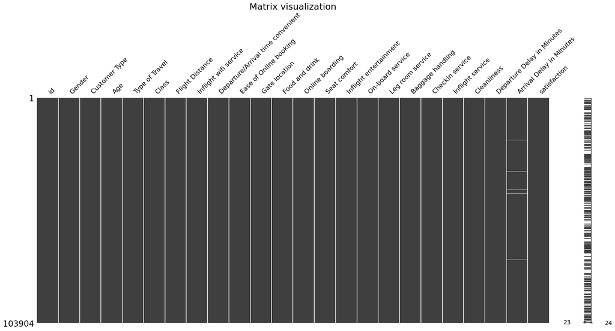

```python
import warnings
warnings.simplefilter('ignore', DeprecationWarning)
%matplotlib inline

import missingno as mn
mn.matrix(df)
# plt.figure()
# mn.matrix(df.sort_values("Arrival Delay in Minutes"))
plt.title("Matrix visualization", fontsize=22)
plt.show()
```

It looks like there's the tiniest amount of missing data for arrival delay column. Let's select those rows:

```python
print("{:.2%}".format(len(df[df["Arrival Delay in Minutes"].isna()])/len(df)))
df[df["Arrival Delay in Minutes"].isna()].describe()
```

```
0.30%
```

|  | id | Age | Flight Distance | Inflight wifi service | Departure/Arrival time convenient | Ease of Online booking | Gate location | Food and drink | Online boarding | Seat comfort | Inflight entertainment | On-board service | Leg room service | Baggage handling | Checkin service | Inflight service | Cleanliness | Departure Delay in Minutes | Arrival Delay in Minutes |
| --- | --- | --- | --- | --- | --- | --- | --- | --- | --- | --- | --- | --- | --- | --- | --- | --- | --- | --- | --- |
| count | 310.000000 | 310.000000 | 310.000000 | 310.000000 | 310.000000 | 310.000000 | 310.000000 | 310.000000 | 310.000000 | 310.000000 | 310.000000 | 310.000000 | 310.000000 | 310.000000 | 310.000000 | 310.000000 | 310.000000 | 310.000000 | 0.0 |
| mean | 58836.183871 | 39.125806 | 1230.609677 | 2.706452 | 3.132258 | 2.729032 | 2.929032 | 3.203226 | 3.209677 | 3.316129 | 3.296774 | 3.300000 | 3.235484 | 3.680645 | 3.293548 | 3.529032 | 3.270968 | 37.432258 | NaN |
| std | 38026.713846 | 15.740626 | 946.334977 | 1.317405 | 1.472045 | 1.399536 | 1.244325 | 1.374993 | 1.376374 | 1.378310 | 1.320362 | 1.311019 | 1.376889 | 1.131176 | 1.267323 | 1.192260 | 1.340481 | 62.239283 | NaN |
| min | 247.000000 | 7.000000 | 77.000000 | 0.000000 | 0.000000 | 0.000000 | 1.000000 | 0.000000 | 0.000000 | 1.000000 | 1.000000 | 1.000000 | 0.000000 | 1.000000 | 1.000000 | 1.000000 | 1.000000 | 0.000000 | NaN |
| 25% | 26121.750000 | 27.000000 | 459.750000 | 2.000000 | 2.000000 | 2.000000 | 2.000000 | 2.000000 | 2.000000 | 2.000000 | 2.000000 | 2.000000 | 2.000000 | 3.000000 | 3.000000 | 3.000000 | 2.000000 | 0.000000 | NaN |
| 50% | 50569.500000 | 39.000000 | 945.000000 | 3.000000 | 3.000000 | 3.000000 | 3.000000 | 3.000000 | 3.000000 | 4.000000 | 4.000000 | 4.000000 | 3.000000 | 4.000000 | 3.000000 | 4.000000 | 3.000000 | 8.000000 | NaN |
| 75% | 96631.750000 | 51.000000 | 1749.000000 | 4.000000 | 4.000000 | 4.000000 | 4.000000 | 4.000000 | 4.000000 | 4.000000 | 4.000000 | 4.000000 | 4.000000 | 5.000000 | 4.000000 | 4.000000 | 4.000000 | 47.500000 | NaN |
| max | 129489.000000 | 72.000000 | 3981.000000 | 5.000000 | 5.000000 | 5.000000 | 5.000000 | 5.000000 | 5.000000 | 5.000000 | 5.000000 | 5.000000 | 5.000000 | 5.000000 | 5.000000 | 5.000000 | 5.000000 | 455.000000 | NaN |

So there are 310 NaN values in over 100k instances. Only 0.3% of the data. While this is a minimal amount and could possibly be ignored or dropped, we think it is best to impute these missing values using K nearest neighbor.

We chose to impute because

1. we wanted to practice
2. we didn't want to exclude outlier or potentially important data

```python
from sklearn.impute import KNNImputer
import copy

# code modified from Data viz lecture notes
# get object for imputation
knn_obj = KNNImputer(n_neighbors=3)

features_to_use = ['Age','Flight Distance','Departure/Arrival time convenient','Departure Delay in Minutes', 'Arrival Delay in Minutes']

# create a numpy matrix from pandas numeric values to impute
temp = df[features_to_use].to_numpy()

# use sklearn imputation object
knn_obj.fit(temp)
temp_imputed = knn_obj.transform(temp)

# Deep copy
df_imputed = copy.deepcopy(df) # not just an alias
df_imputed[features_to_use] = temp_imputed
df_imputed.dropna(inplace=True)
df_imputed.info()
```

```
<class 'pandas.core.frame.DataFrame'>
Int64Index: 103904 entries, 0 to 103903
Data columns (total 24 columns):
 #   Column                             Non-Null Count   Dtype
---  ------                             --------------   -----
 0   id                                 103904 non-null  int64
 1   Gender                             103904 non-null  object
 2   Customer Type                      103904 non-null  object
 3   Age                                103904 non-null  float64
 4   Type of Travel                     103904 non-null  object
 5   Class                              103904 non-null  object
 6   Flight Distance                    103904 non-null  float64
 7   Inflight wifi service              103904 non-null  int64
 8   Departure/Arrival time convenient  103904 non-null  float64
 9   Ease of Online booking             103904 non-null  int64
```

[output cut: 16 more lines]

Now lets check if there are any duplicate data. Since each entry has an ID, we suspect that there are none, but we thought it would be worth checking just in case.

```python
idx = df_imputed.duplicated()

len(df_imputed[idx])
```

```
0
```

As suspected, there are no duplicate values in the dataset. However, as we will discuss later, no duplicate data does not mean that the data is entirely clean.

Various fields in the dataset were text covering demographic information. For analysis, it is possible to convert them to integers in order to more easily run statistical analysis without needing natural language processing (for example, Customer Type and Class could become integer values since they have a hierarchy).

Additionally, some fields are continuous, but it would be more useful if they were grouped into ranges instead. For this we are adding a field called age_range that groups ages into subgroups.

```python
# visualize the conversion
previous_customer_type = pd.DataFrame(
    {'original': df['Customer Type'],
    'new': df['Customer Type'].map({'disloyal Customer': 0, 'Loyal Customer': 1})},
    columns=['original', 'new']
)
print(previous_customer_type)

# visualize the conversion
previous_class = pd.DataFrame(
    {'original': df['Class'],
    'new': df['Class'].map({'Eco': 1, 'Eco Plus': 2, 'Business': 3})},
    columns=['original', 'new']
)
print(previous_class)

df_imputed['age_range'] = pd.cut(df_imputed['Age'],
                                 [0,13,17,30,55,1e6],
                                 labels=['child','teen','young adult','adult','senior']) # this creates a new variable
df_imputed.age_range.describe()

df_grouped = df_imputed.groupby(by=['age_range'])
df_grouped.mean()
```

```
                 original  new
0          Loyal Customer    1
1       disloyal Customer    0
2          Loyal Customer    1
3          Loyal Customer    1
4          Loyal Customer    1
...                   ...  ...
103899  disloyal Customer    0
103900     Loyal Customer    1
103901  disloyal Customer    0
103902  disloyal Customer    0
103903     Loyal Customer    1

[103904 rows x 2 columns]
        original  new
0       Eco Plus    2
1       Business    3
2       Business    3
3       Business    3
4       Business    3
...          ...  ...
103899       Eco    1
103900  Business    3
103901  Business    3
103902       Eco    1
103903  Business    3

[103904 rows x 2 columns]
```

| age_range | id | Age | Flight Distance | Inflight wifi service | Departure/Arrival time convenient | Ease of Online booking | Gate location | Food and drink | Online boarding | Seat comfort | Inflight entertainment | On-board service | Leg room service | Baggage handling | Checkin service | Inflight service | Cleanliness | Departure Delay in Minutes | Arrival Delay in Minutes |
| --- | --- | --- | --- | --- | --- | --- | --- | --- | --- | --- | --- | --- | --- | --- | --- | --- | --- | --- | --- |
| child | 64923.657528 | 10.041786 | 910.235463 | 2.543002 | 3.401282 | 2.556268 | 2.946717 | 2.985408 | 2.555384 | 2.948707 | 3.012160 | 3.223745 | 3.211585 | 3.671236 | 3.210701 | 3.695777 | 3.001990 | 15.327438 | 15.744786 |
| teen | 63622.221538 | 15.633803 | 939.279636 | 2.620305 | 3.290200 | 2.614437 | 3.004988 | 3.097711 | 2.680164 | 3.062500 | 3.130869 | 3.176056 | 3.195423 | 3.685446 | 3.196009 | 3.697183 | 3.113263 | 15.333627 | 16.158646 |
| young adult | 63980.036937 | 24.586683 | 1037.830138 | 2.701925 | 2.858253 | 2.732136 | 2.969145 | 3.185612 | 2.897527 | 3.144929 | 3.193789 | 3.241924 | 3.208612 | 3.679006 | 3.232982 | 3.685370 | 3.200435 | 15.173769 | 15.636336 |
| adult | 65132.524012 | 43.090884 | 1303.066604 | 2.781757 | 3.059242 | 2.804192 | 2.989631 | 3.241656 | 3.449346 | 3.598033 | 3.483404 | 3.479124 | 3.461818 | 3.646888 | 3.352300 | 3.654933 | 3.362816 | 14.790207 | 15.220260 |
| senior | 65903.139561 | 61.787560 | 1173.002478 | 2.675617 | 3.222412 | 2.724124 | 2.949841 | 3.178744 | 3.431075 | 3.570164 | 3.336422 | 3.362445 | 3.273988 | 3.493273 | 3.301959 | 3.502006 | 3.278355 | 14.131417 | 14.406389 |

### Easy Question: Are people generally satisfied with their flights?

```python
print("{:.2%}".format(len(df_imputed[df_imputed['satisfaction'] == 'satisfied'])/len(df_imputed)))
```

```
43.33%
```

no. :(

## Data Visualization

### General exploration

What do satisfied and dissatisfied respondents look like?

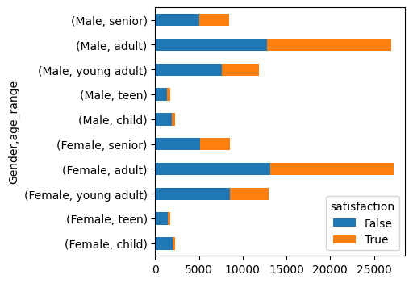

```python
df_imputed_satisfaction = copy.deepcopy(df_imputed)
df_imputed_satisfaction['satisfaction'] = df_imputed['satisfaction'].map({'neutral or dissatisfied': 0, 'satisfied': 1})

pp = pd.crosstab([df_imputed_satisfaction['Gender'],
                        df_imputed_satisfaction['age_range']], # categories to cross tabulate
                       df_imputed_satisfaction.satisfaction.astype(bool)) # how to group

pp.plot(kind='barh', stacked=True,figsize=[4,4])
plt.show()
```

Adults have the highest satisfaction rate by far according to this. Could this be because mostly adults are flying business class (better seats and perks)?

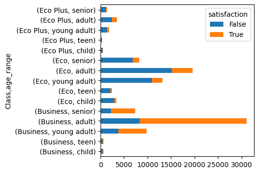

```python
pp = pd.crosstab([df_imputed_satisfaction['Class'],
                        df_imputed_satisfaction['age_range']], # categories to cross tabulate
                       df_imputed_satisfaction.satisfaction.astype(bool)) # how to group

pp.plot(kind='barh', stacked=True, figsize=[4,4])
plt.show()
```

It looks like this thesis was correct! Business travellers are

1. mostly adults
2. much more likely to be satisfied

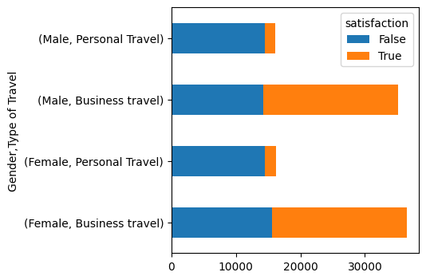

```python
pp = pd.crosstab([df_imputed_satisfaction['Gender'],
                        df_imputed_satisfaction['Type of Travel']], # categories to cross tabulate
                       df_imputed_satisfaction.satisfaction.astype(bool)) # how to group

pp.plot(kind='barh', stacked=True, figsize=[4,4])
plt.show()
```

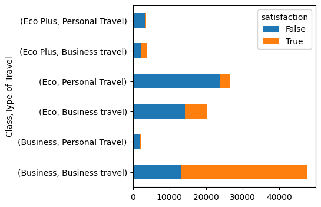

```python
pp = pd.crosstab([df_imputed_satisfaction['Class'],
                        df_imputed_satisfaction['Type of Travel']], # categories to cross tabulate
                       df_imputed_satisfaction.satisfaction.astype(bool)) # how to group

pp.plot(kind='barh', stacked=True, figsize=[4,4])
plt.show()
```

Our thesis was correct! Most of these passengers were not flying business class on personal travel It is a little weird that even passengers who were on personal travel and flew business were dissatisfied. Perhaps there is another variable that is more highly correlated with satisfaction...

This opens up an interesting question that is a little more substantive that we should answer!

### Question: Which fields have the highest correlation with overall satisfaction?

```
Correlation to overall satisfaction by percentage
satisfaction                         1.000000
Online boarding                      0.503557
Inflight entertainment               0.398059
Seat comfort                         0.349459
On-board service                     0.322383
Leg room service                     0.313131
Cleanliness                          0.305198
Flight Distance                      0.298780
Inflight wifi service                0.284245
Baggage handling                     0.247749
Inflight service                     0.244741
Checkin service                      0.236174
Food and drink                       0.209936
Ease of Online booking               0.171705
Age                                  0.137167
id                                   0.013734
Gate location                        0.000682
Departure Delay in Minutes          -0.050494
Departure/Arrival time convenient   -0.051601
Arrival Delay in Minutes            -0.057558
Name: satisfaction, dtype: float64
```

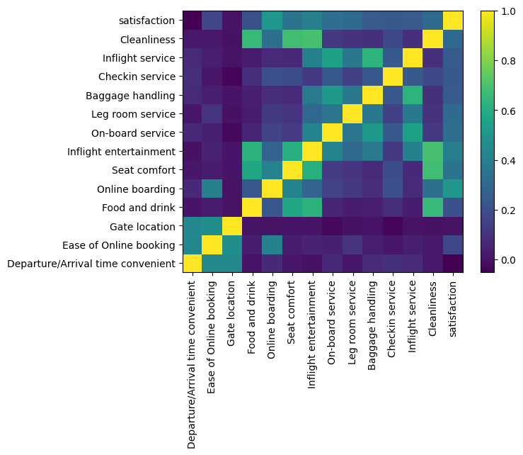

```python
import numpy as np

#create a deep copy of the imputed data in order to convert the satisfaction text into 1's and 0's
df_convert=copy.deepcopy(df_imputed)
df_convert['satisfaction'] = (df_imputed['satisfaction']=='satisfied').astype(int)

# print the correlation of all values and sort them from largest to smallest
print('Correlation to overall satisfaction by percentage')
print((df_convert.corr()['satisfaction'].sort_values(ascending=False)))

vars_to_use = [
    'Departure/Arrival time convenient',
    'Ease of Online booking',
    'Gate location',
    'Food and drink',
    'Online boarding',
    'Seat comfort',
    'Inflight entertainment',
    'On-board service',
    'Leg room service',
    'Baggage handling',
    'Checkin service',
    'Inflight service',
    'Cleanliness',
    'satisfaction'
]
plt.pcolor(df_convert[vars_to_use].corr())

plt.yticks(np.arange(0.5, len(vars_to_use), 1), vars_to_use)
plt.xticks(np.arange(0.5, len(vars_to_use), 1), vars_to_use, rotation=90)
plt.colorbar()
plt.show()
```

From the correlation percentages, it's pretty clear that some ratings have a much heavier weight in the overall satisfaction decision. For example, the online boarding rating has a correlation of over 50%, but with the gate location rating, the correlation is essentially 0%. This correlation percentage can give us a preliminary view into what fields might be relevant when attempting to do predictive analysis on the dataset.

The correlation chart shows the relative sameness of the various ratings that customers filled out in their satisfaction survey. What is immediately obvious is that cleanliness, food and drink, and inflight entertainment have a pretty high correlation with each other, but the vast majority of the other ratings do not. This suggests two things. First, that all of the ratings are fairly unique, and thus shouldn't be combined with each other, and second, that even people who rate some things highly will still rate others poorly, and so a rating being low or high does not give us much information on what other ratings may be.

In other words, in order to decrease the amount of math required, we cannot combine fields together, since they are all pretty different, but instead we need to eliminate fields that don't have a significant effect on the final predictive result. This is the purpose of the final element in the correlation matrix, which correlates all of the individual ratings to overall satisfaction.

### Question: Which fields are more biased towards positive or negative satisfaction ratings?

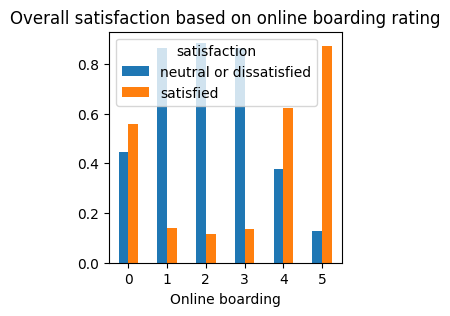

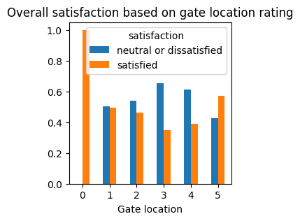

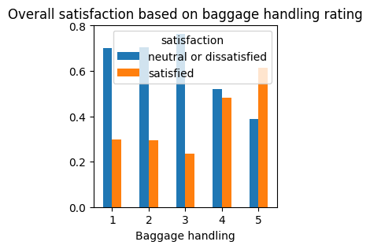

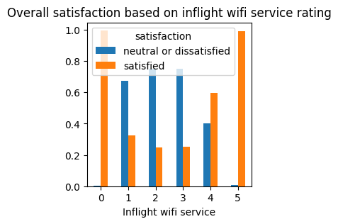

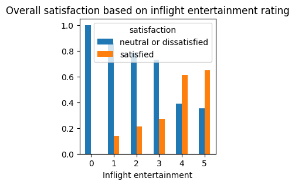

```python
# visualize a discrete satisfaction graph on a field with high correlation to overall satisfaction
df_grouped = df_imputed.groupby(by='Online boarding')
df_class_satisfaction = df_grouped['satisfaction'].value_counts(normalize=True)
pltt = df_class_satisfaction.unstack().plot(kind='bar', rot=0, figsize=[3,3])
pltt.set_title('Overall satisfaction based on online boarding rating')

# visualize a discrete satisfaction graph on a field with low correlation to overall satisfaction
df_grouped = df_imputed.groupby(by='Gate location')
df_class_satisfaction = df_grouped['satisfaction'].value_counts(normalize=True)
pltt = df_class_satisfaction.unstack().plot(kind='bar', rot=0, figsize=[3,3])
pltt.set_title('Overall satisfaction based on gate location rating')

# visualize a discrete satisfaction graph on a field with high correlation to negative overall satisfaction
df_grouped = df_imputed.groupby(by='Baggage handling')
df_class_satisfaction = df_grouped['satisfaction'].value_counts(normalize=True)
pltt = df_class_satisfaction.unstack().plot(kind='bar', rot=0, figsize=[3,3])
pltt.set_title('Overall satisfaction based on baggage handling rating')

# visualize a discrete satisfaction graph on a field with a not-applicable option
df_grouped = df_imputed.groupby(by='Inflight wifi service')
df_class_satisfaction = df_grouped['satisfaction'].value_counts(normalize=True)
pltt = df_class_satisfaction.unstack().plot(kind='bar', rot=0, figsize=[3,3])
pltt.set_title('Overall satisfaction based on inflight wifi service rating')

# visualize a discrete satisfaction graph on a field with a not-applicable option
df_grouped = df_imputed.groupby(by='Inflight entertainment')
df_class_satisfaction = df_grouped['satisfaction'].value_counts(normalize=True)
pltt = df_class_satisfaction.unstack().plot(kind='bar', rot=0, figsize=[3,3])
pltt.set_title('Overall satisfaction based on inflight entertainment rating')
```

Something else that is important to note is that some ratings have a much heavier effect on the negative side, without much effect towards a positive satisfaction rating, whereas other ratings are the exact opposite. For example, baggage handling is pretty far down the list in terms of correlation to overall satisfaction- only 25%, but when we visualize the graph, we can see that the data is massively skewed towards negative overall satisfaction when the baggage handling rating is low (between 1-3). For online boarding, there are spikes for both the negative and the positive sides. From these graphs, we can gather that it will be important for our analysis to categorize ratings into ones that have more effect on a negative rating, ones that have more effect on a positive rating, and ones that have an effect on both.

For the last 2 graphs where they had significant N/A responses, we noticed that for inflight wifi ratings, those without wifi had 99.7% satisfaction ratings (out of over 3000 responses), whereas those who had wifi that was poor got very high dissatisfaction results. In other words, for inflight wifi, no wifi is better than bad wifi. Information like this suggests that the N/A ratings can help airlines determine whether an amenity is worth spending money on and providing to the customer. A great example of this is the inflight entertainment. No inflight entertainment resulted in 100% dissatisfaction (albeit with only 14 responses), and increasing levels of inflight entertainment resulted in more satisfaction.

### Question: Is correlation percentage a defining factor when determining the importance of a given field?

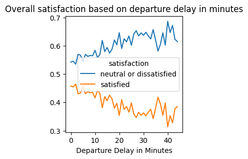

```python
# visualize a continous satisfaction graph on a field with low correlation to overall satisfaction
#Using the 90th percentile of data because of the massive tail of the data.
df_grouped = df_imputed[df_imputed['Departure Delay in Minutes'] <= df_imputed['Departure Delay in Minutes'].quantile(.9) ].groupby(by='Departure Delay in Minutes')
df_age_satisfaction = df_grouped['satisfaction'].value_counts(normalize=True)
pltt = df_age_satisfaction.unstack().plot(kind='line', figsize=[3,3])
pltt.set_title('Overall satisfaction based on departure delay in minutes')
```

The correlation percentage between overall satisfaction and departure delay is negative, but when we actually graph the relationship, we can see that increasing departure delay results in decreasing overall satisfaction. From this we can gather that correlation can give us hints as to what fields might be important or relevant, but in order to get more specific data, we need to graph and visualize the fields to determine whether or not a relationship that can be used to perform predictive analysis exists.

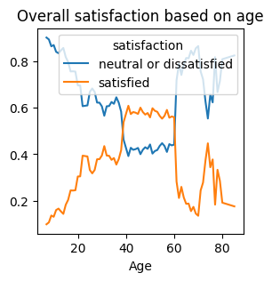

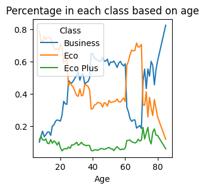

```python
# visualize a continous satisfaction graph based on the age of the customer
df_grouped = df_imputed.groupby(by='Age')
df_age_satisfaction = df_grouped['satisfaction'].value_counts(normalize=True)
pltt = df_age_satisfaction.unstack().plot(kind='line', figsize=(3,3))
pltt.set_title('Overall satisfaction based on age')

# visualize the percentage of customers in each class based on the age of the customer
df_grouped = df_imputed.groupby(by='Age')
df_age_satisfaction = df_grouped['Class'].value_counts(normalize=True)
pltt = df_age_satisfaction.unstack().plot(kind='line', figsize=(3,3))
pltt.set_title('Percentage in each class based on age')
```

## Additional (Arguably Exceptional) Work

### Trend for "Not Applicable" instances

Why? Because we have an expectation that if there is no wifi, in-flight bev service, and other amenities, that will substantially impact the satisfaction of passengers, but we'd like to see!

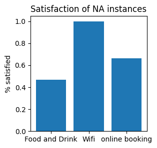

```python
# len(df_imputed[df_imputed['Inflight wifi service'] == 0])
# len(df_imputed[df_imputed['Departure/Arrival time convenient'] == 0])
# len(df_imputed[df_imputed['Ease of Online booking'] == 0])

no_fnb = df_imputed[df_imputed['Food and drink'] == 0]
no_wifi = df_imputed[df_imputed['Inflight wifi service'] == 0]
no_onlb = df_imputed[df_imputed['Ease of Online booking'] == 0]
x = len(no_fnb[no_fnb['satisfaction'] == 'satisfied']) / len(no_fnb)
y = len(no_wifi[no_wifi['satisfaction'] == 'satisfied']) / len(no_wifi)
z = len(no_onlb[no_onlb['satisfaction'] == 'satisfied']) / len(no_onlb)

plt.figure(figsize=(3,3))
plt.bar(['Food and Drink','Wifi','online booking'],[x,y,z])
plt.title('Satisfaction of NA instances')
plt.ylabel('% satisfied')
```

### Visualizing a field to find potential abnormalities in responses

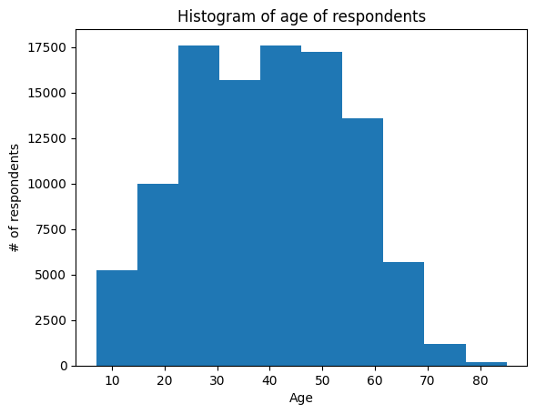

```python
%matplotlib inline
plt.hist(df_imputed['Age'])
plt.xlabel('Age')
plt.ylabel('# of respondents')

plt.title('Histogram of age of respondents')
```

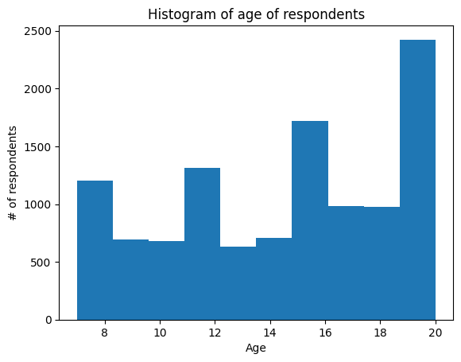

```python
df_age = df_imputed[df_imputed["Age"] <= 20]
plt.hist(df_age['Age'])
plt.xlabel('Age')
plt.ylabel('# of respondents')
plt.title('Histogram of age of respondents')
```

Do we really think that 5,000+ people within the age of 10 filled out this survey? Do we value the responses of this demographic group?

What's also a little off is the big peaks in the data. We would normally expect this to be smoothed out. Let's plot this as a line for this age group to see if it's smoother or not.

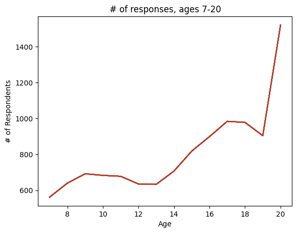

```python
plt.plot(df_age.groupby("Age").count())
plt.xlabel("Age")
plt.ylabel("# of Respondents")
plt.title("# of responses, ages 7-20")
plt.show()
```

Looks much smoother! Let's apply this plotting to all of our data

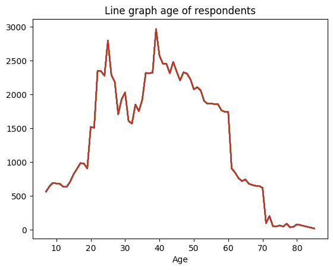

```python
plt.plot(df_imputed.groupby("Age").count())
plt.title("Line graph age of respondents")
plt.xlabel("Age")
plt.show()
```

After looking at it from this lens, it is also curious why there is such a big drop off in age at 60. Is there an intuitive explanation for this? Maybe people are retiring? If that's the case then this chart will look very different for people on business and not.

```
% on personal travel: 31.04%
```

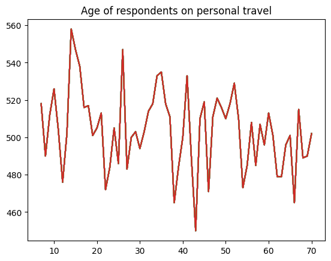

```python
print("% on personal travel: "+"{:.2%}".format(len(df_imputed[df_imputed["Type of Travel"] == "Personal Travel"])/len(df_imputed)))
plt.plot(df_imputed[df_imputed["Type of Travel"] == "Personal Travel"].groupby("Age").count())
plt.title("Age of respondents on personal travel")
```

This data is very sparse and noisy. That's a little concerning and something we didn't expect. This data makes up a **third** of all of our data, yet it's so noisy!

This being said, the dropoff in age is much less pronounced. Can we still try to explain the big dropoff in age? I think it's possible that those over 70 booked their reservations by some other method than online; I think this would be non-response bias in our data

### Visualizing data with large outliers

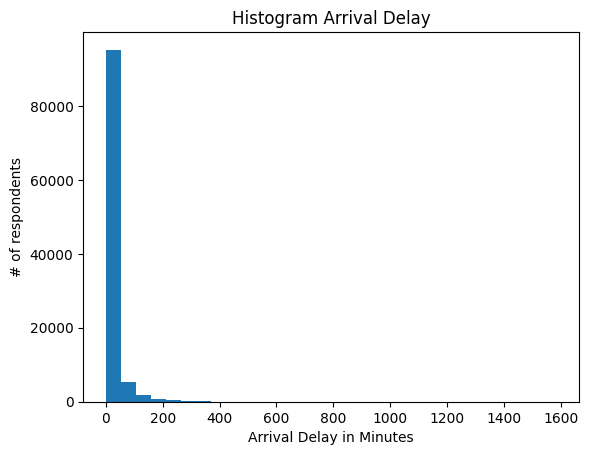

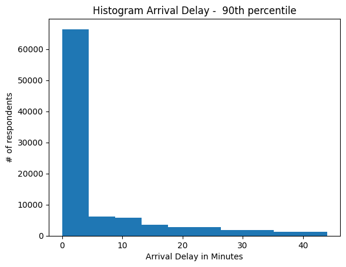

```python
%matplotlib inline
plt.hist(df_imputed["Arrival Delay in Minutes"],30)
plt.xlabel('Arrival Delay in Minutes')
plt.ylabel('# of respondents')
plt.title('Histogram Arrival Delay')
plt.show()
plt.clf()
# plt.hist(df_imputed["Arrival Delay in Minutes"].quantile(.75),20)
# plt.show()
df_arrival = df_imputed[df_imputed['Arrival Delay in Minutes'] <= df_imputed['Arrival Delay in Minutes'].quantile(.9) ]
plt.hist(df_arrival['Arrival Delay in Minutes'])
plt.xlabel('Arrival Delay in Minutes')
plt.ylabel('# of respondents')
plt.title('Histogram Arrival Delay -  90th percentile')
plt.show()
plt.clf()
```

For the arrival delay feature, there is a very small number of large delays in minutes, which causes the graph to be skewed disproportionately towards those few large delays. To combat this, we instead only graph up to the 90th percentile of responses in order to get data that is more useful.

### Violin plot analysis

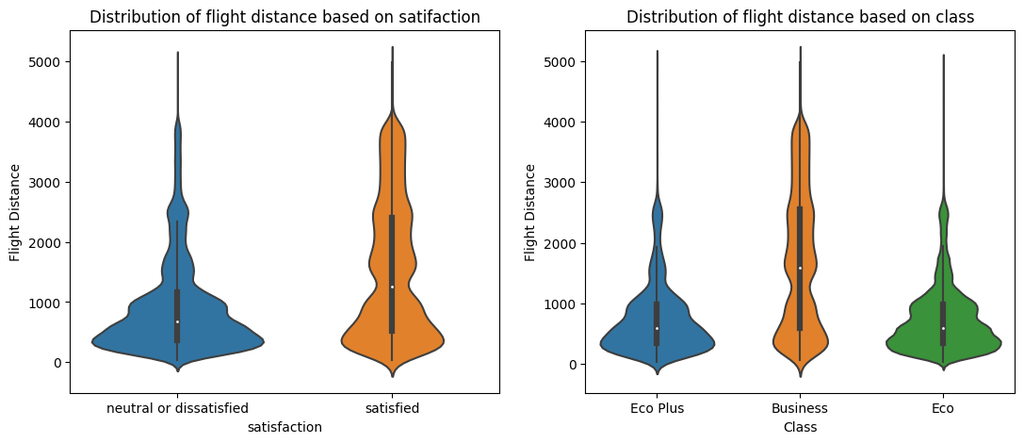

```python
# plot a violin plot to show satisfaction based on flight distance and customer type

plt.subplots(figsize=(20,5))


plt.subplot(1,3,1)
sns.violinplot(x="satisfaction", y="Flight Distance", data=df_imputed)
plt.title('Distribution of flight distance based on satifaction')

plt.subplot(1,3,2)
sns.violinplot(x="Class", y="Flight Distance", data=df_imputed)
plt.title('Distribution of flight distance based on class')

plt.show()

# use age
```

From the first graph, we see that the vast majority of dissatisfied customers were on short flights, and that the satisfied customers show a more even distribution. From the second graph we can gather that the vast majority of eco and eco plus flights were also short flights, and that those who flew business class had a more even distribution of flight distances. The shape of these violin plots suggests that there may be a correlation between eco flights (which also tend to be shorter flights) and dissatisfaction, as well as business class flights (whose distance is more evenly distributed) and satisfaction.

If the first graph had flipped violin plots, i.e. neutral or dissatisfied had its bulge in the shorter flight distance, and satisfied had a bulge at the longer flight distance, that would suggest a relationship between flight distance and satisfaction. However, since that is not the case, the second graph exists to show the indirect relationship to another field, which in this case is the class of the flight.

```python
df_grouped = df_imputed.groupby(by=['age_range'])
df_grouped.mean()
```

| age_range | id | Age | Flight Distance | Inflight wifi service | Departure/Arrival time convenient | Ease of Online booking | Gate location | Food and drink | Online boarding | Seat comfort | Inflight entertainment | On-board service | Leg room service | Baggage handling | Checkin service | Inflight service | Cleanliness | Departure Delay in Minutes | Arrival Delay in Minutes |
| --- | --- | --- | --- | --- | --- | --- | --- | --- | --- | --- | --- | --- | --- | --- | --- | --- | --- | --- | --- |
| child | 64923.657528 | 10.041786 | 910.235463 | 2.543002 | 3.401282 | 2.556268 | 2.946717 | 2.985408 | 2.555384 | 2.948707 | 3.012160 | 3.223745 | 3.211585 | 3.671236 | 3.210701 | 3.695777 | 3.001990 | 15.327438 | 15.744786 |
| teen | 63622.221538 | 15.633803 | 939.279636 | 2.620305 | 3.290200 | 2.614437 | 3.004988 | 3.097711 | 2.680164 | 3.062500 | 3.130869 | 3.176056 | 3.195423 | 3.685446 | 3.196009 | 3.697183 | 3.113263 | 15.333627 | 16.158646 |
| young adult | 63980.036937 | 24.586683 | 1037.830138 | 2.701925 | 2.858253 | 2.732136 | 2.969145 | 3.185612 | 2.897527 | 3.144929 | 3.193789 | 3.241924 | 3.208612 | 3.679006 | 3.232982 | 3.685370 | 3.200435 | 15.173769 | 15.636336 |
| adult | 65132.524012 | 43.090884 | 1303.066604 | 2.781757 | 3.059242 | 2.804192 | 2.989631 | 3.241656 | 3.449346 | 3.598033 | 3.483404 | 3.479124 | 3.461818 | 3.646888 | 3.352300 | 3.654933 | 3.362816 | 14.790207 | 15.220260 |
| senior | 65903.139561 | 61.787560 | 1173.002478 | 2.675617 | 3.222412 | 2.724124 | 2.949841 | 3.178744 | 3.431075 | 3.570164 | 3.336422 | 3.362445 | 3.273988 | 3.493273 | 3.301959 | 3.502006 | 3.278355 | 14.131417 | 14.406389 |

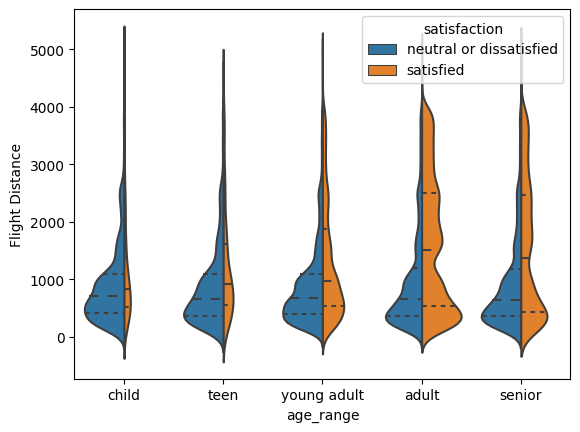

```python
sns.violinplot(x="age_range", y="Flight Distance", hue="satisfaction", data=df_imputed,
               split=True,
               inner="quart",
               scale="count")
plt.show()
```

From the graph above, we can see that the age range seem to be very correlated to how satisfied the customer is with longer flight distances. Both children, teens, and most young adults seems to rarely be satisfied with their flights, despite only experiencing shorter flights in comparison to the higher age ranges. Adults and seniors both have longer flights and are more satisfied with those flights.

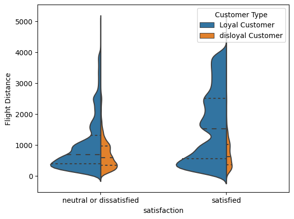

```python
import seaborn as sns

sns.violinplot(x="satisfaction", y="Flight Distance", hue="Customer Type", data=df_imputed,
               split=True,
               inner="quart",
               scale="count")
plt.show()
```

From the graph, we can see that loyal customers tend to fly more often, seen through the higher presence of data from loyal customers, and fly longer. Contrastingly, the disloyal customers tend to fly shorter distances despite their satisfaction. The shape of these plots seem to suggest a correlation between distance and satisfaction, at least pertaining to loyal customers. There also seems to be a correlation between loyalty and distance, which makes sense as a frequent flyer would most likely choose to become a loyal customer for price and rewards sake.

This project was completed for CS5324 taught by Dr. Eric Larson at SMU.

[figure not shown]

Created in Deepnote